# NRCS RPP Soil Features Tutorial

This guide explains, in plain language, what the soil features in the Site Assessment Agent are doing and how they influence:

- the maps you see
- the resource concerns that are flagged
- the practices that become most relevant

## 1) Where Soil Features Appear in the App

[figure not shown]

App overview with AOI workflow and map layers

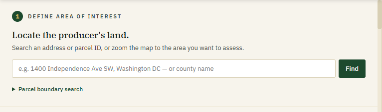

AOI workflow panel on the left sidebar

The soil workflow starts after AOI definition and boundary drawing. Once analysis runs, the app combines SSURGO + CART interpretation logic + concern mapping to populate:

- Soil Resource Inventory
- CART Soil Analytics
- Potential Resource Concerns
- Resource Concern Evidence Report / Analysis Report

A small but important control is the map-layer panel:

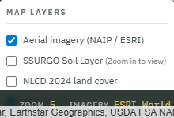

Map layers panel

This panel controls the base layers while soil thematic layers are tied to concern/practice analysis.

## 2) Soil Feature Pipeline (What Happens Behind the Scenes)

1. The app reads SSURGO component/map unit properties for the AOI.
2. It computes or aligns CART-style interpretation metrics (for key soil-health and management limits).
3. It maps soil evidence to resource concerns using the Soil Property -> Resource Concern matrix logic.
4. It selects a thematic map key for each concern and practice (for visual explanation on the map).
5. It surfaces key evidence in concern cards and reports.

Think of each soil feature as an evidence signal. Multiple features combine to create the concern ranking.

## 3) Thematic Soil Features and What They Do

The app groups soil features into four practical categories.

## Water Management Features

### Hydrologic Soil Group (HSG)

- What it is: runoff/infiltration class (A through D).
- Why it matters: stronger runoff potential raises water-quality and erosion concerns.
- In app behavior: frequently used for runoff-linked concerns and contour/strip practices.

### Flooding Frequency

- What it is: how often flooding is expected.
- Why it matters: high frequency increases risk to water quality, root health, and field operability.
- In app behavior: supports ponding/flooding and seasonal water-table concern logic.

### Ponding Frequency (%)

- What it is: percent likelihood/frequency of surface ponding.
- Why it matters: indicates poor drainage and oxygen stress risk.
- In app behavior: contributes to wetness-related concern evidence.

### Depth to Water Table

- What it is: shallowest expected depth to saturated zone.
- Why it matters: shallow depth limits rooting, trafficability, and nutrient/pesticide fate.
- In app behavior: key input for seasonal high-water-table, seep, and drainage-related concern evidence.

### Available Water Supply (0-150 cm)

- What it is: plant-available water storage in the profile.
- Why it matters: low values increase drought stress and irrigation sensitivity.
- In app behavior: drives naturally available moisture concern context and irrigation-focused practice interpretation.

### Saturated Hydraulic Conductivity (Ksat)

- What it is: saturated water movement through soil.
- Why it matters: very low Ksat can increase runoff/perching; very high Ksat can increase leaching vulnerability.
- In app behavior: used across groundwater/surface-water transport concern logic.

## Soil Property Features

### Organic Matter (0-25 cm)

- What it is: near-surface organic matter level.
- Why it matters: supports structure, infiltration, nutrient cycling, and resilience.
- In app behavior: baseline evidence plus relationship to organic matter depletion risk.

### Clay Content (0-25 cm)

- What it is: percent clay in topsoil.
- Why it matters: influences water movement, swelling/shrink behavior, and compaction response.
- In app behavior: helps explain aggregate/compaction behavior and practice fit.

### Bulk Density

- What it is: soil mass per volume (g/cm3).
- Why it matters: high bulk density often indicates tighter pore space and rooting limitations.
- In app behavior: major contributor to compaction-style concerns.

### Electrical Conductivity (EC)

- What it is: dissolved salt indicator (dS/m).
- Why it matters: elevated salinity can reduce crop performance and affect water quality.
- In app behavior: supports salts-related concern evidence.

## Erosion and Topography Features

### Slope (%)

- What it is: terrain steepness.
- Why it matters: steeper slopes generally increase runoff velocity and erosion hazard.
- In app behavior: central input for sheet/rill, gully, and ephemeral gully concern logic.

### Erodibility K-factor

- What it is: susceptibility of soil to detachment/transport by rainfall and runoff.
- Why it matters: higher erodibility increases sediment risk.
- In app behavior: key erosion evidence shown repeatedly in concern cards/reports.

### Depth to Bedrock

- What it is: depth to restrictive rock layer.
- Why it matters: shallower depth limits rooting volume and storage capacity.
- In app behavior: used for seep/subsurface and drought-storage interpretations.

## CART Interpretation Features

### Organic Matter Depletion Risk

- What it is: interpretation of likely OM decline pressure.
- Why it matters: indicates long-term soil-function vulnerability.
- In app behavior: default thematic signal for several regenerative practices.

### Susceptibility to Compaction

- What it is: interpretation of compaction sensitivity.
- Why it matters: helps plan traffic/tillage/grazing adjustments.
- In app behavior: highlighted for compaction-related concerns and grazing/tillage practice fit.

### Suitability for Aerobic Organisms

- What it is: indicator of oxygen-friendly habitat conditions.
- Why it matters: biological activity depends on favorable aeration and moisture balance.
- In app behavior: used in soil-health style concern framing.

### Surface Salt Concentration

- What it is: interpretation of near-surface salinity pressure.
- Why it matters: salinity stress can limit establishment and productivity.
- In app behavior: supports salts concern evidence and visualization.

## 4) How Features Become Resource Concerns

The app does not rely on one value alone. It uses combinations. Examples:

- Sheet and rill erosion: often weighted by slope + K-factor + hydrologic group.
- Compaction: often weighted by bulk density + clay + compaction susceptibility.
- Nutrients to groundwater: often weighted by Ksat + depth to water table + available water storage.
- Ponding/flooding: often weighted by flooding frequency + ponding + water-table depth.

This is why concern cards show multiple evidence lines instead of a single trigger.

## 5) How Features Influence Practice Fit

The same soil features are reused to explain practice relevance. Example patterns in the app logic:

- Cover/rotation systems: emphasize OM depletion and erosion indicators.
- Drainage water management: emphasizes depth to water table and wetness indicators.
- Grazing management: emphasizes compaction susceptibility and soil resilience.
- Irrigation water management: emphasizes available water supply and profile-water behavior.

So concerns identify what is happening now; practice fit indicates what can improve those conditions.

## 6) How to Read the Reports

When you open the reports, read in this order:

1. Concern title and rank/order.
2. Key soil evidence lines under that concern.
3. Land-use context (cropland/pasture/forest).
4. Practice recommendations tied to those same soil signals.

If a recommendation seems surprising, check whether one strong limiting feature (for example shallow water table, steep slope, or high K-factor) is dominating the concern ranking.

## 7) Quick Interpretation Tips for Field Use

- Do not treat one feature in isolation.
- Watch for stacked risk signals (for example high slope + high K-factor + low cover).
- Use wetness indicators together (flooding, ponding, water table) before selecting drainage-related strategies.
- Use OM + bulk density + compaction susceptibility together for soil-health management choices.

## 8) Practical Bottom Line

In this app, soil features are the evidence layer. They are used to:

- diagnose likely resource concerns
- visualize where the concern pressure comes from
- justify why certain practices rise to the top

That evidence-first flow is what keeps recommendations consistent with actual soil limitations and opportunities.